# Introduction

The primary objective of this project is to develop a predictive model for the target variable, "Weather Type", based on a given set of features in the dataset. Accurate predictions of weather types can provide valuable insights for applications such as climate analysis, forecasting, and decision-making in weather-dependent industries.

To achieve this goal, we will undertake the following steps:

Exploratory Data Analysis (EDA): Understand the dataset's structure, assess data quality, and identify patterns or relationships among features.

Model Development: Train multiple machine learning models to identify the one that performs best for classifying "Weather Type."

Model Evaluation: Evaluate model performance using metrics such as accuracy, F1-score, and precision-recall analysis. Use cross-validation to ensure generalization across datasets.

Threshold Optimization: Fine-tune model thresholds to improve class-specific predictions and maximize relevant metrics.

Model Optimization and Deployment: Implement strategies to ensure the final model is robust, interpretable, and ready for application.

By the end of this project, we aim to present a well-validated predictive model for "Weather Type" that achieves optimal performance while providing actionable insights into the relationships between features and weather classifications.

```python
import pandas as pd
import numpy as np
from sklearn.svm import SVC
from sklearn.ensemble import RandomForestClassifier
from sklearn.tree import DecisionTreeClassifier
from sklearn.linear_model import Lasso
from sklearn.metrics import confusion_matrix, classification_report , accuracy_score
from sklearn.metrics import precision_recall_curve, f1_score
from sklearn.model_selection import GridSearchCV,train_test_split
import seaborn as sns
import matplotlib.pyplot as plt
from sklearn.preprocessing import LabelEncoder
from sklearn.preprocessing import StandardScaler
```

```python
data = pd.read_csv('weather_classification_data.csv')
data
```

|  | Temperature | Humidity | Wind Speed | Precipitation (%) | Cloud Cover | Atmospheric Pressure | UV Index | Season | Visibility (km) | Location | Weather Type |
| --- | --- | --- | --- | --- | --- | --- | --- | --- | --- | --- | --- |
| 0 | 14.0 | 73 | 9.5 | 82.0 | partly cloudy | 1010.82 | 2 | Winter | 3.5 | inland | Rainy |
| 1 | 39.0 | 96 | 8.5 | 71.0 | partly cloudy | 1011.43 | 7 | Spring | 10.0 | inland | Cloudy |
| 2 | 30.0 | 64 | 7.0 | 16.0 | clear | 1018.72 | 5 | Spring | 5.5 | mountain | Sunny |
| 3 | 38.0 | 83 | 1.5 | 82.0 | clear | 1026.25 | 7 | Spring | 1.0 | coastal | Sunny |
| 4 | 27.0 | 74 | 17.0 | 66.0 | overcast | 990.67 | 1 | Winter | 2.5 | mountain | Rainy |
| ... | ... | ... | ... | ... | ... | ... | ... | ... | ... | ... | ... |
| 13195 | 10.0 | 74 | 14.5 | 71.0 | overcast | 1003.15 | 1 | Summer | 1.0 | mountain | Rainy |
| 13196 | -1.0 | 76 | 3.5 | 23.0 | cloudy | 1067.23 | 1 | Winter | 6.0 | coastal | Snowy |
| 13197 | 30.0 | 77 | 5.5 | 28.0 | overcast | 1012.69 | 3 | Autumn | 9.0 | coastal | Cloudy |
| 13198 | 3.0 | 76 | 10.0 | 94.0 | overcast | 984.27 | 0 | Winter | 2.0 | inland | Snowy |
| 13199 | -5.0 | 38 | 0.0 | 92.0 | overcast | 1015.37 | 5 | Autumn | 10.0 | mountain | Rainy |

13200 rows × 11 columns

# EDA

```python
#summary of data
data.describe()
```

|  | Temperature | Humidity | Wind Speed | Precipitation (%) | Atmospheric Pressure | UV Index | Visibility (km) |
| --- | --- | --- | --- | --- | --- | --- | --- |
| count | 13200.000000 | 13200.000000 | 13200.000000 | 13200.000000 | 13200.000000 | 13200.000000 | 13200.000000 |
| mean | 19.127576 | 68.710833 | 9.832197 | 53.644394 | 1005.827896 | 4.005758 | 5.462917 |
| std | 17.386327 | 20.194248 | 6.908704 | 31.946541 | 37.199589 | 3.856600 | 3.371499 |
| min | -25.000000 | 20.000000 | 0.000000 | 0.000000 | 800.120000 | 0.000000 | 0.000000 |
| 25% | 4.000000 | 57.000000 | 5.000000 | 19.000000 | 994.800000 | 1.000000 | 3.000000 |
| 50% | 21.000000 | 70.000000 | 9.000000 | 58.000000 | 1007.650000 | 3.000000 | 5.000000 |
| 75% | 31.000000 | 84.000000 | 13.500000 | 82.000000 | 1016.772500 | 7.000000 | 7.500000 |
| max | 109.000000 | 109.000000 | 48.500000 | 109.000000 | 1199.210000 | 14.000000 | 20.000000 |

```python
data.describe(include="object")
```

|  | Cloud Cover | Season | Location | Weather Type |
| --- | --- | --- | --- | --- |
| count | 13200 | 13200 | 13200 | 13200 |
| unique | 4 | 4 | 3 | 4 |
| top | overcast | Winter | inland | Rainy |
| freq | 6090 | 5610 | 4816 | 3300 |

```python
#data types
data.info()
```

```
<class 'pandas.core.frame.DataFrame'>
RangeIndex: 13200 entries, 0 to 13199
Data columns (total 11 columns):
 #   Column                Non-Null Count  Dtype
---  ------                --------------  -----
 0   Temperature           13200 non-null  float64
 1   Humidity              13200 non-null  int64
 2   Wind Speed            13200 non-null  float64
 3   Precipitation (%)     13200 non-null  float64
 4   Cloud Cover           13200 non-null  object
 5   Atmospheric Pressure  13200 non-null  float64
 6   UV Index              13200 non-null  int64
 7   Season                13200 non-null  object
 8   Visibility (km)       13200 non-null  float64
 9   Location              13200 non-null  object
 10  Weather Type          13200 non-null  object
dtypes: float64(5), int64(2), object(4)
memory usage: 1.1+ MB
```

```python
#checks # of null
data.isnull().sum()
```

```
Temperature             0
Humidity                0
Wind Speed              0
Precipitation (%)       0
Cloud Cover             0
Atmospheric Pressure    0
UV Index                0
Season                  0
Visibility (km)         0
Location                0
Weather Type            0
dtype: int64
```

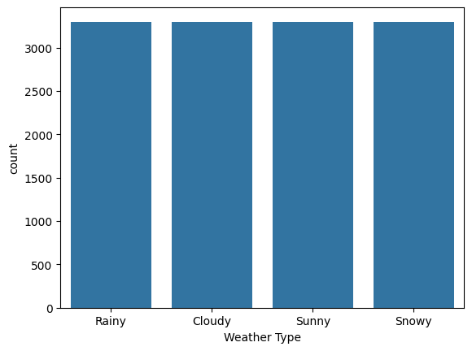

```python
# Checks class blance of target variable
sns.countplot(x='Weather Type',data=data)
```

# Data Manipulation

```python
# Apply label encoder encoding
# Initialize LabelEncoder
label_encoder = LabelEncoder()

# Apply LabelEncoder to each categorical column
data['Cloud Cover'] = label_encoder.fit_transform(data['Cloud Cover'])
data['Season'] = label_encoder.fit_transform(data['Season'])
data['Location'] = label_encoder.fit_transform(data['Location'])
data['Weather Type'] = label_encoder.fit_transform(data['Weather Type'])
```

# Feature Selection

```python
#Lasso regression will be used for feature selection
X = data.drop(columns = 'Weather Type')
y = data['Weather Type']
#scale X to keep uniform scales
scaler =StandardScaler()
x_scaled = scaler.fit_transform(X)
#fitting model
model = Lasso(alpha = 0.01, random_state = 10)
model.fit(x_scaled,y)
```

```
Lasso(alpha=0.01, random_state=10)
```

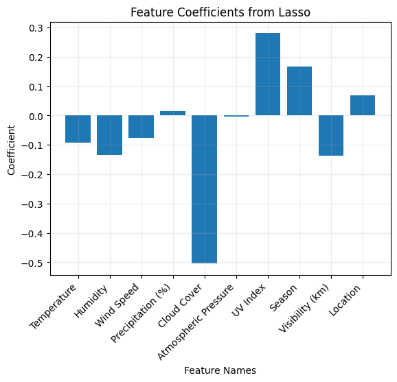

```python
feature_names = X.columns
coeff = model.coef_

plt.bar(feature_names,coeff)
plt.xlabel('Feature Names')
plt.ylabel('Coefficient')
plt.title('Feature Coefficients from Lasso')
plt.xticks(rotation=45,ha='right')
plt.grid(alpha=0.25)
```

```python
feature_importance_pairs = list(zip(feature_names,coeff))
sorted_features = sorted(feature_importance_pairs, key=lambda x: abs(x[1]), reverse=True)
sorted_features
```

```
[('Cloud Cover', -0.5047075358401044),
 ('UV Index', 0.2800420264371193),
 ('Season', 0.16761188390457077),
 ('Visibility (km)', -0.1372371821623578),
 ('Humidity', -0.13553635746121578),
 ('Temperature', -0.09328914797979801),
 ('Wind Speed', -0.0760714166933155),
 ('Location', 0.06807886938130794),
 ('Precipitation (%)', 0.014362410929389198),
 ('Atmospheric Pressure', -0.0045881046503950616)]
```

```python
top = [x[0] for x in sorted_features]

X_train, X_test, y_train, y_test = train_test_split(X,y, stratify=y, random_state=10)

#scale X to keep uniform scales
scaler =StandardScaler()
x_train_scaled = scaler.fit_transform(X_train)
x_test_scaled = scaler.transform(X_test)

scores = []

for i in range(1,11):
    selected_features = top[:i]
    X_train_subset = X_train[selected_features]
    X_test_subset = X_test[selected_features]

    model = RandomForestClassifier(random_state=10, n_jobs = -1)
    model.fit(X_train_subset,y_train)

    score = model.score(X_test_subset, y_test)
    scores.append(score)
print(scores)
```

```
[0.5112121212121212, 0.6690909090909091, 0.7533333333333333, 0.8536363636363636, 0.8536363636363636, 0.9018181818181819, 0.9027272727272727, 0.9093939393939394, 0.906969696969697, 0.9154545454545454]
```

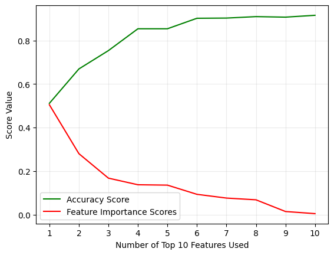

```python
importance_scores = [abs(x[1]) for x in sorted_features]

plt.plot(np.arange(1,len(scores)+1),scores, label = 'Accuracy Score', c ='g', linestyle='solid')
plt.xlabel("Number of Top 10 Features Used")
plt.ylabel("Score Value")
plt.grid(alpha=0.25)
plt.xticks(np.arange(1,len(scores)+1))

plt.plot(np.arange(1,len(scores)+1),importance_scores,label = 'Feature Importance Scores',c='r',linestyle = 'solid')
plt.legend()
plt.show()
```

# ML Modeling

```python
#From the score graph above, 6 features of feature selection is ideal.

X = data[top[:6]]
y = data['Weather Type']

X_train, X_test, y_train, y_test = train_test_split(X,y, stratify=y, random_state=10)

#scale X to keep uniform scales
scaler =StandardScaler()
x_train_scaled = scaler.fit_transform(X_train)
x_test_scaled = scaler.transform(X_test)
```

```python
# Define the model
svm = SVC(probability=True, random_state=10)

# Define parameter grid
param_grid = {
    'C': [0.1, 1, 10],
    'kernel': ['linear', 'rbf'],
    'gamma': ['scale', 'auto']
}

# Perform Grid Search
grid_svm = GridSearchCV(estimator=svm, param_grid=param_grid, cv=5, scoring='roc_auc_ovr',verbose=2 )
grid_svm.fit(x_train_scaled, y_train)

# Best parameters and score
print("Best Parameters for SVM:", grid_svm.best_params_)
print("Best Score for SVM:", grid_svm.best_score_)
```

[output not shown]

[output cut: 8 more lines]

[output not shown]

```python
# Define the model
decision_tree = DecisionTreeClassifier(random_state=10)

# Define parameter grid
param_grid = {
    'max_depth': [3, 5, 10, None],
    'min_samples_split': [2, 5, 10],
    'min_samples_leaf': [1, 2, 4]
}

# Perform Grid Search
grid_tree = GridSearchCV(estimator=decision_tree, param_grid=param_grid, cv=5, scoring='roc_auc_ovr',verbose=2 )
grid_tree.fit(x_train_scaled, y_train)

# Best parameters and score
print("Best Parameters for Decision Tree:", grid_tree.best_params_)
print("Best Score for Decision Tree:", grid_tree.best_score_)
```

[output not shown]

[output cut: 128 more lines]

[output not shown]

```python
random_forest = RandomForestClassifier(random_state=10)

# Define parameter grid
param_grid = {
    'n_estimators': [100, 200, 500],
    'max_depth': [None,5, 10, 20],
    'min_samples_split': [2, 5, 10],
    'max_features': ['sqrt', 'log2']
}

# Perform Grid Search
grid_rf = GridSearchCV(estimator=random_forest, param_grid=param_grid, cv=5, scoring='roc_auc_ovr',verbose=2 )
grid_rf.fit(x_train_scaled, y_train)

# Best parameters and score
print("Best Parameters for Random Forest:", grid_rf.best_params_)
print("Best Score for Random Forest:", grid_rf.best_score_)
```

[output not shown]

[output cut: 308 more lines]

[output not shown]

# Model Selection

```python
#Since the random forest gave the best roc_auc score, we will be using random forest with its observed best parameters.

rf = RandomForestClassifier(max_depth= 10, max_features = 'sqrt', min_samples_split = 10, n_estimators=500)
rf.fit(x_train_scaled, y_train)

rf.score(x_test_scaled,y_test)

y_pred=rf.predict(x_test_scaled)
```

# First Evaluation

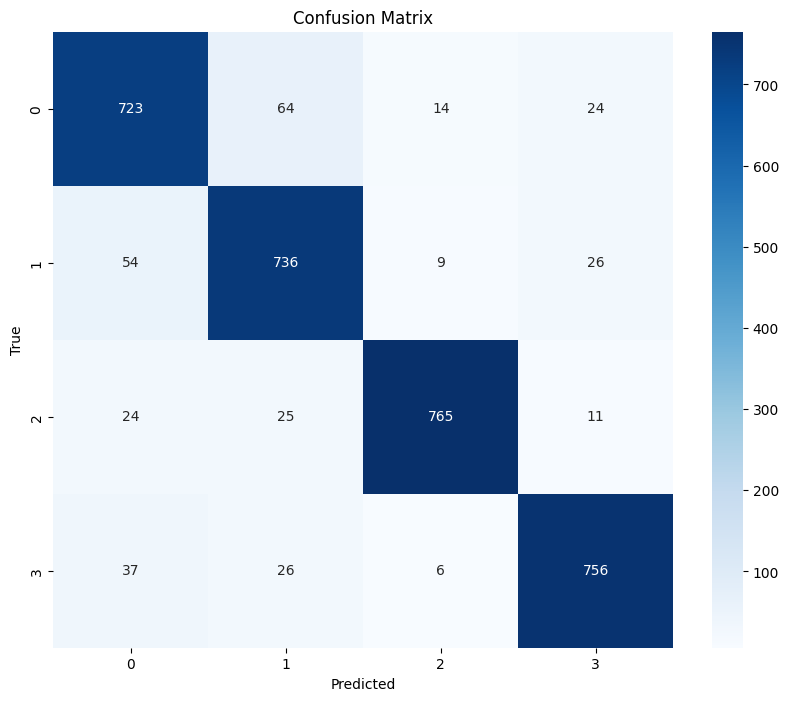

```python
from sklearn.metrics import confusion_matrix
import seaborn as sns
import matplotlib.pyplot as plt

cm = confusion_matrix(y_test, y_pred)

plt.figure(figsize=(10, 8))
sns.heatmap(cm, annot=True, fmt='d', cmap='Blues',annot_kws={"size": 10})
plt.xlabel("Predicted")
plt.ylabel("True")
plt.title("Confusion Matrix")
plt.show()
```

```python
from sklearn.metrics import classification_report

report = classification_report(y_test, y_pred)
print("Classification Report:")
print(report)
```

```
Classification Report:
              precision    recall  f1-score   support

           0       0.86      0.88      0.87       825
           1       0.86      0.89      0.88       825
           2       0.96      0.93      0.95       825
           3       0.93      0.92      0.92       825

    accuracy                           0.90      3300
   macro avg       0.90      0.90      0.90      3300
weighted avg       0.90      0.90      0.90      3300
```

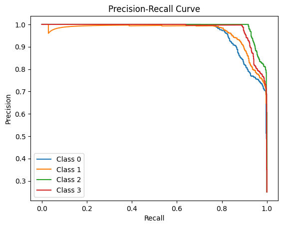

```python
from sklearn.metrics import precision_recall_curve
y_probs = rf.predict_proba(x_test_scaled)
# Plot Precision-Recall Curve for each class
for i in range(y_probs.shape[1]):
    precision, recall, thresholds = precision_recall_curve(y_test == i, y_probs[:, i])
    plt.plot(recall, precision, label=f"Class {i}")
plt.xlabel("Recall")
plt.ylabel("Precision")
plt.title("Precision-Recall Curve")
plt.legend()
plt.show()
```

# Model Optimization by finding the best threshold

```python
n_classes = y_probs.shape[1]  # Number of classes
best_thresholds = []  # To store the best thresholds for each class

for i in range(n_classes):
    # Compute precision, recall, and thresholds for each class
    precision, recall, thresholds = precision_recall_curve(y_test == i, y_probs[:, i])


    best_f1 = 0
    best_threshold = 0

    # Iterate over thresholds to compute F1-score
    for threshold in thresholds:
        # Generate binary predictions for the current threshold
        y_pred_class_i = (y_probs[:, i] >= threshold).astype(int)
        y_true_class_i = (y_test == i).astype(int)

        # Compute F1-score using the library
        score = f1_score(y_true_class_i, y_pred_class_i)

        # Update the best F1-score and threshold
        if score > best_f1:
            best_f1 = score
            best_threshold = threshold

    # Store the best threshold for the current class
    best_thresholds.append(best_threshold)

    print(f"Class {i}: Best Threshold = {best_threshold:.2f}, F1-Score = {best_f1:.2f}")

print("Best Thresholds for Each Class:", best_thresholds)
```

```
Class 0: Best Threshold = 0.57, F1-Score = 0.89
Class 1: Best Threshold = 0.45, F1-Score = 0.90
Class 2: Best Threshold = 0.50, F1-Score = 0.96
Class 3: Best Threshold = 0.64, F1-Score = 0.94
Best Thresholds for Each Class: [0.5742247363552804, 0.4456026923809683, 0.5026671499470622, 0.6424077327724697]
```

```python
y_pred = np.zeros_like(y_probs)

for i, threshold in enumerate(best_thresholds):
    y_pred[:, i] = (y_probs[:, i] >= threshold).astype(int)

# Convert probabilities to final class predictions
y_pred_class = y_pred.argmax(axis=1)
```

# Second Evaluation

```python
print("Original Classification Report:")
print(classification_report(y_test, rf.predict(x_test_scaled)))

print("Optimized Classification Report:")
print(classification_report(y_test, y_pred_class))
```

```
Original Classification Report:
              precision    recall  f1-score   support

           0       0.86      0.88      0.87       825
           1       0.86      0.89      0.88       825
           2       0.96      0.93      0.95       825
           3       0.93      0.92      0.92       825

    accuracy                           0.90      3300
   macro avg       0.90      0.90      0.90      3300
weighted avg       0.90      0.90      0.90      3300

Optimized Classification Report:
              precision    recall  f1-score   support

           0       0.76      0.95      0.84       825
           1       0.93      0.88      0.90       825
           2       1.00      0.92      0.96       825
           3       1.00      0.89      0.94       825

    accuracy                           0.91      3300
   macro avg       0.92      0.91      0.91      3300
weighted avg       0.92      0.91      0.91      3300
```

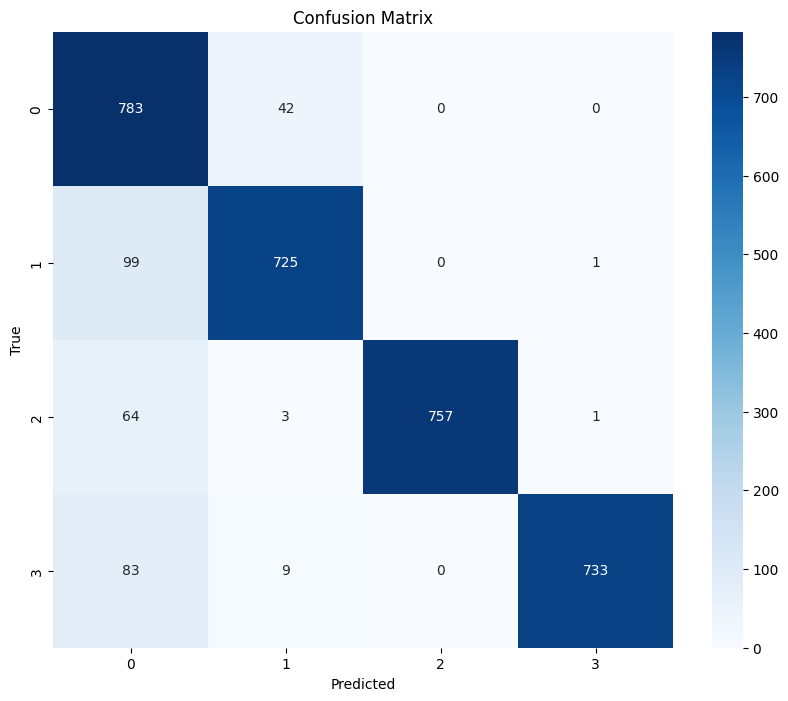

```python
cm = confusion_matrix(y_test, y_pred_class)

plt.figure(figsize=(10, 8))
sns.heatmap(cm, annot=True, fmt='d', cmap='Blues',annot_kws={"size": 10})
plt.xlabel("Predicted")
plt.ylabel("True")
plt.title("Confusion Matrix")
plt.show()
```

# Conclusion

The overall results indicate that:

1. the model successfully predicts the target variable, "Weather Type", with high accuracy.
2. Threshold optimization improved the classification performance.
3. The approach of feature engineering using Lasso regression, model evaluation using confusion matrix, ROC-AUC score, f1-score, accuracy score, precison and recall scores, and model optimization through finding appropriate threshold provided robust and reliable predictive model.